# Telecom Customer Churn Prediction

Jahnavi Saikia

April 26, 2019

##### **Problem Statement**

Churning in the telecom industry implies customers changing the service providers. In telecom domain where the customer acquisition has higher cost than customer retention and where there is a rampant price war, it becomes important to predict and profile the customer behavior and predict them so that offers can be rolled out to retain them prior to switching.

###### **Objective**

**1.** Exploring the the data through visualization to understand the current state and various factors (or combination of factors) which is contributing to customer churn.

**2.** Develop a prediction algorithm to predict customer churn.

**3.** Model evaluation and explaination of the metrics chosen for the model.

**4.** What extra features could have made the model better and give a better explanation of the factors leading to churn

**5.** Based on the descriptive analytics and model results try to come up with a strategy to arrest customer churn.

Data provided consist of the various behavior of customers and the last column states if the customer is still with the existing telecom company or not.

**// Loading Packages //**

**// Reading the dataset & Checking the structure of the data //**

```r
#setwd("C:/Users/sony/Desktop/DIAGEO")
Churn_data<- read.csv('data.csv', header=TRUE)
str(Churn_data)
```

```
## 'data.frame':    3333 obs. of  21 variables:
##  $ Id                    : Factor w/ 3333 levels "CUST-1","CUST-10",..: 1 1112 2223 2668 2779 2890 3001 3112 3223 2 ...
##  $ State                 : Factor w/ 51 levels "AK","AL","AR",..: 17 36 32 36 37 2 20 25 19 50 ...
##  $ Account.length        : int  128 107 137 84 75 118 121 147 117 141 ...
##  $ Area.code             : int  415 415 415 408 415 510 510 415 408 415 ...
##  $ International.plan    : Factor w/ 2 levels "No","Yes": 1 1 1 2 2 2 1 2 1 2 ...
##  $ Voice.mail.plan       : Factor w/ 2 levels "No","Yes": 2 2 1 1 1 1 2 1 1 2 ...
##  $ Number.vmail.messages : int  25 26 0 0 0 0 24 0 0 37 ...
##  $ Total.day.minutes     : num  265 162 243 299 167 ...
##  $ Total.day.calls       : int  110 123 114 71 113 98 88 79 97 84 ...
##  $ Total.day.charge      : num  45.1 27.5 41.4 50.9 28.3 ...
##  $ Total.eve.minutes     : num  197.4 195.5 121.2 61.9 148.3 ...
##  $ Total.eve.calls       : int  99 103 110 88 122 101 108 94 80 111 ...
##  $ Total.eve.charge      : num  16.78 16.62 10.3 5.26 12.61 ...
##  $ Total.night.minutes   : num  245 254 163 197 187 ...
##  $ Total.night.calls     : int  91 103 104 89 121 118 118 96 90 97 ...
##  $ Total.night.charge    : num  11.01 11.45 7.32 8.86 8.41 ...
##  $ Total.intl.minutes    : num  10 13.7 12.2 6.6 10.1 6.3 7.5 7.1 8.7 11.2 ...
##  $ Total.intl.calls      : int  3 3 5 7 3 6 7 6 4 5 ...
##  $ Total.intl.charge     : num  2.7 3.7 3.29 1.78 2.73 1.7 2.03 1.92 2.35 3.02 ...
##  $ Customer.service.calls: int  1 1 0 2 3 0 3 0 1 0 ...
##  $ Churn                 : logi  FALSE FALSE FALSE FALSE FALSE FALSE ...
```

The raw data contains 3333 rows (customers) and 21 columns (features). The “Churn” column is our target.

**// Checking for missing values in the dataset //**

```r
sapply(Churn_data, function(x) sum(is.na(x)))
```

```
##                     Id                  State         Account.length
##                      0                      0                      0
##              Area.code     International.plan        Voice.mail.plan
##                      0                      0                      0
##  Number.vmail.messages      Total.day.minutes        Total.day.calls
##                      0                      0                      0
##       Total.day.charge      Total.eve.minutes        Total.eve.calls
##                      0                      0                      0
##       Total.eve.charge    Total.night.minutes      Total.night.calls
##                      0                      0                      0
##     Total.night.charge     Total.intl.minutes       Total.intl.calls
##                      0                      0                      0
##      Total.intl.charge Customer.service.calls                  Churn
##                      0                      0                      0
```

There is no missing value in the given dataset.

**// Checking for total no of churned customer in the given dataset for better understanding //**

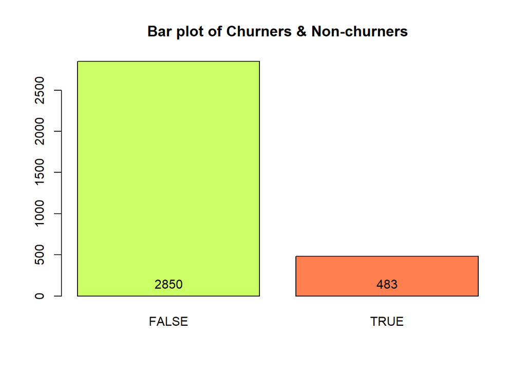

```r
text(barplot(table(Churn_data$Churn),col=c('#CCFF66','coral'),main='Bar plot of Churners & Non-churners')
     ,0,table(Churn_data$Churn),cex=1,pos=3)
```

The above plot shows that 483 customers have churned and 2850 customers have not churned

**// Exploratory data analysis //**

Deep diving into the data with graphs for better understanding

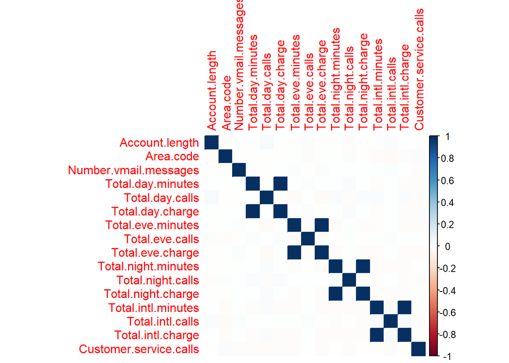

```r
corrplot::corrplot(cor(Churn_data[sapply(Churn_data, is.numeric)]),method="color")
```

**Visualization of Churners & Non-Churners for customers availing International plan or Voice mail Plan**

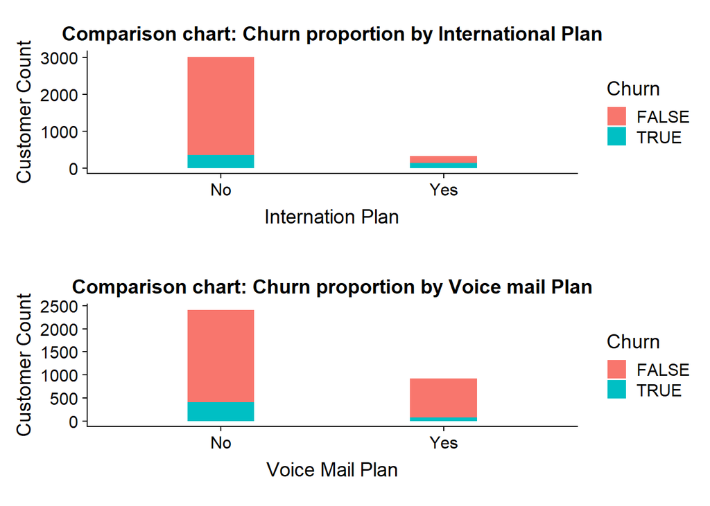

```r
p1<-ggplot(Churn_data ,aes(x=Churn_data$International.plan, fill=Churn)) +
 geom_bar(width=0.3)+
 ylab("Customer Count")+
 xlab("Internation Plan")+
 ggtitle("Comparison chart: Churn proportion by International Plan")+
 theme(aspect.ratio = 1/4)

p2<-ggplot(Churn_data ,aes(x=Churn_data$Voice.mail.plan, fill=Churn)) +
 geom_bar(width=0.3)+
 xlab("Voice Mail Plan")+
 ylab("Customer Count")+
 ggtitle("Comparison chart: Churn proportion by Voice mail Plan")+
   theme(aspect.ratio = 1/4)

grid.arrange(p1,p2,ncol=1)
```

###### Observations:

1. *Customers without International Plan*:-Most of the customers(~3000) donot have International Plan.Number of customers **churned**is also **very minimal** in this category.
2. *Customers with International Plan*:-A very small number customers subscribed to International Plan.Customers **churned vs not churned** is almost of equal proportion in this category.

**Boxplot to see account length behaviour for Churned / Not Churned Customers**

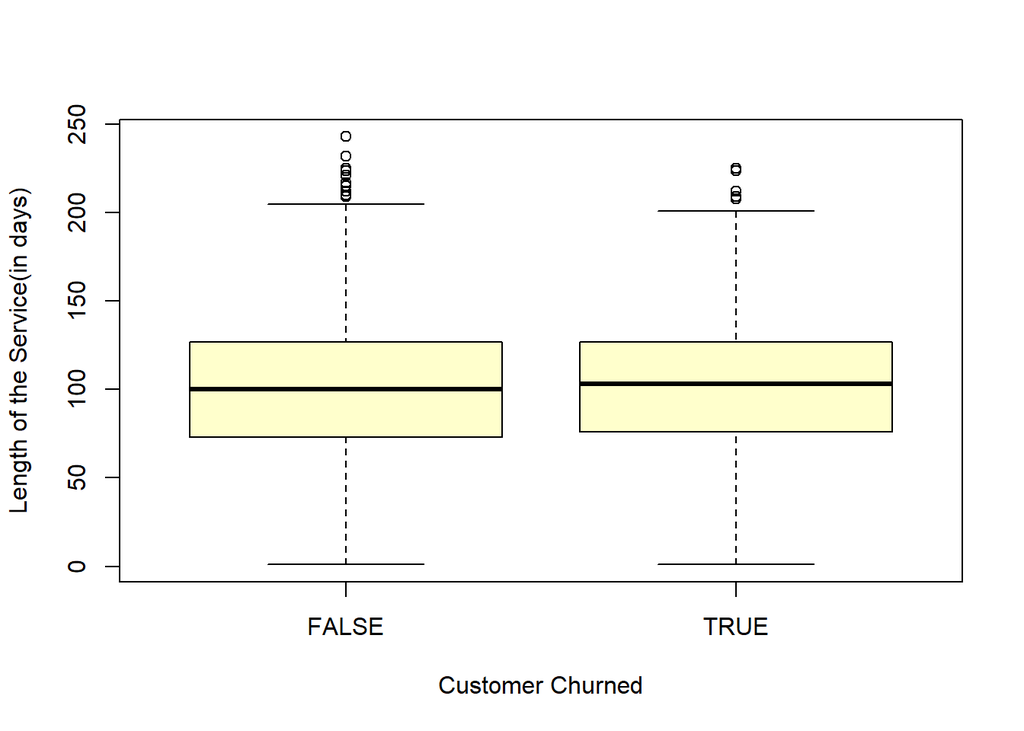

```r
boxplot(Churn_data$Account.length ~ Churn_data$Churn, col = "#FFFFCC",
       xlab = "Customer Churned",ylab = "Length of the Service(in days)")
```

###### Observations:

The box plot doesn’t show any obvious difference between churned vs non churned customers based on account length.

**Boxplot to see the pattern of Total Minutes (Day/Evening/Night/International) for Churned /Not Churned Customers**

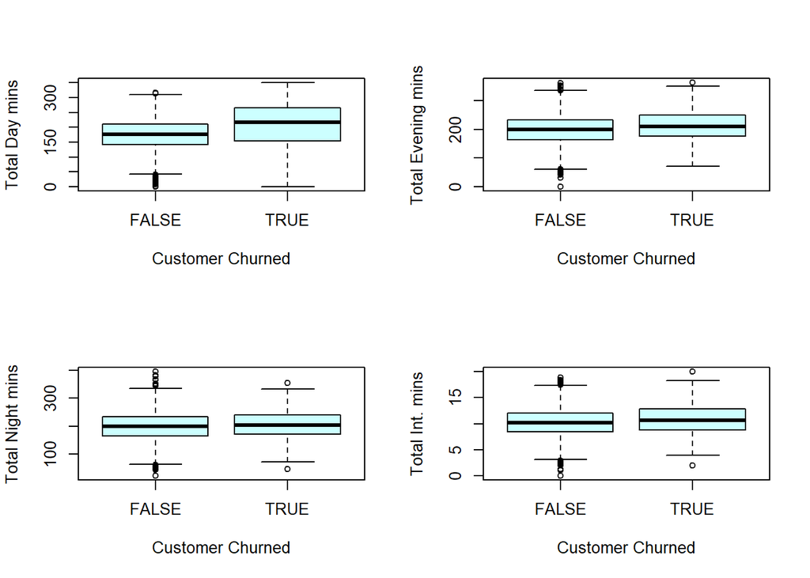

```r
par(mfrow = c(2,2))
boxplot(Churn_data$Total.day.minutes ~ Churn_data$Churn, col = "#CCFFFF",
        xlab = "Customer Churned",ylab = "Total Day mins")
boxplot(Churn_data$Total.eve.minutes ~ Churn_data$Churn, col = "#CCFFFF",
        xlab = "Customer Churned",ylab = "Total Evening mins")
boxplot(Churn_data$Total.night.minutes ~ Churn_data$Churn, col = "#CCFFFF",
        xlab = "Customer Churned",ylab = "Total Night mins")
boxplot(Churn_data$Total.intl.minutes ~ Churn_data$Churn,col = "#CCFFFF",
        xlab = "Customer Churned",ylab = "Total Int. mins")
```

###### Observations:

1. *Total Day Minutes*:-The 1st quartile (Q1),3rd quartile(Q3) , inter quartile range(IQR) for churned customer is higher than the non churned customers which implies that day minutes usage of churned customer is more than that of non churned customers.
2. *Total evening minutes*:-Customers churned show a higher Q1, Q3 & IQR indicating ithat usage of total evening minues possibly is a significant factor in this scenario.
3. *Total night minutes*:-There is no significant difference in usage of night minutes between Churned vs Non Churned customers.
4. *Total international minutes*:-Usage of Churned customer is higher than the non churned customers.

**Boxplot to see the pattern of Total Calls (Day/Evening/Night/International) for Churned / Not Churned Customers**

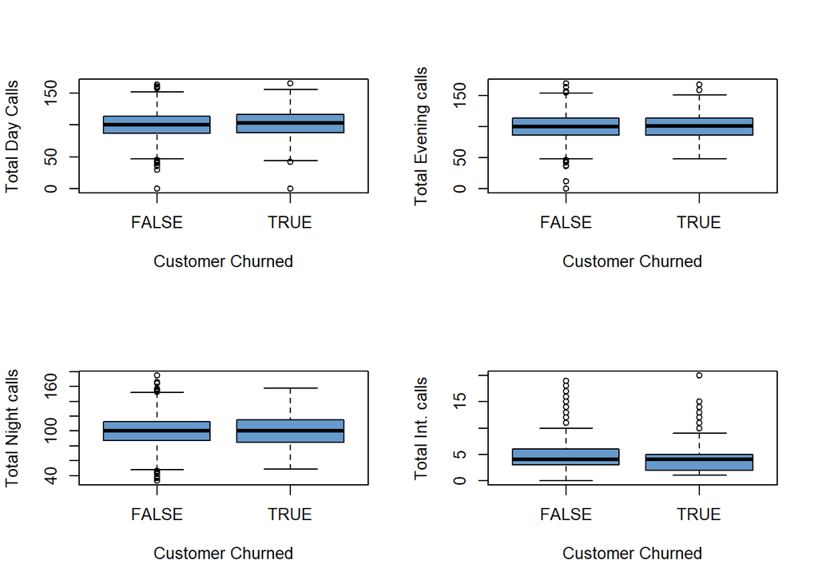

```r
par(mfrow = c(2,2))
boxplot(Churn_data$Total.day.calls ~ Churn_data$Churn, col = "#6699CC",
        xlab = "Customer Churned",ylab = "Total Day Calls")
boxplot(Churn_data$Total.eve.calls ~ Churn_data$Churn, col = "#6699CC",
        xlab = "Customer Churned",ylab = "Total Evening calls")
boxplot(Churn_data$Total.night.calls ~ Churn_data$Churn, col = "#6699CC",
        xlab = "Customer Churned",ylab = "Total Night calls")
boxplot(Churn_data$Total.intl.calls ~ Churn_data$Churn,col = "#6699CC",
        xlab = "Customer Churned",ylab = "Total Int. calls")
```

###### Observations:

1. There is no significant difference observed between Curned & non Churned customers in case of **Day call, Evening Calls**
2. For **Night Calls** inter quartile spread is comparatively higher for churned customers.
3. For **International Calls** upper whisker is higher for non churned customers. If we compare this with the total International minutes graph we can conclude that
- Not churned customer make higher number of calls but for lesser duration
- Churned customers make fewer calls but the duration is relatively longer.

**Boxplot to see the pattern of Total Charges (Day/Evening/Night/International) for Churned / Not Churned Customers**

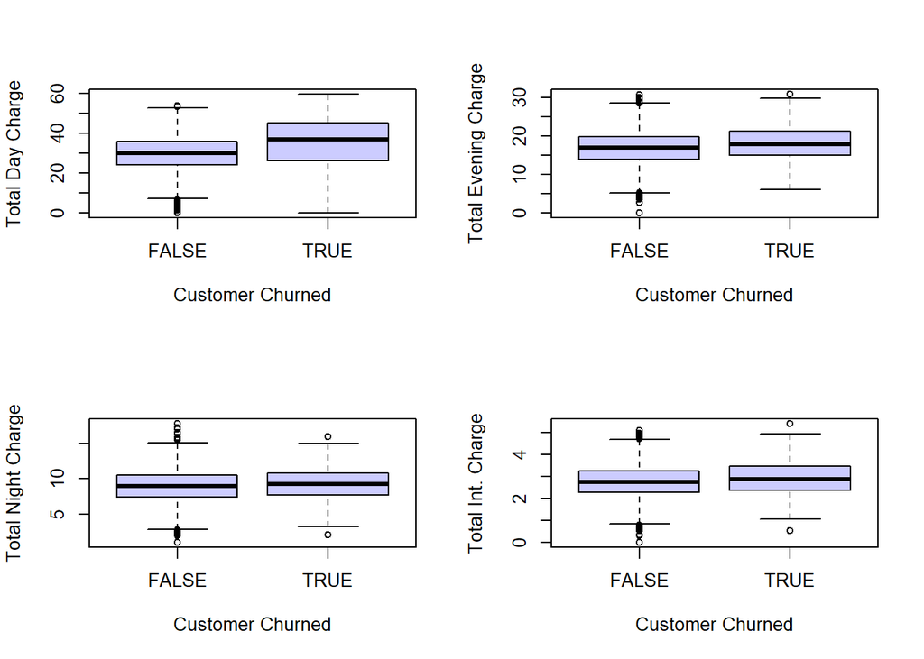

```r
par(mfrow = c(2,2))
boxplot(Churn_data$Total.day.charge ~ Churn_data$Churn, col = "#CCCCFF",
        xlab = "Customer Churned",ylab = "Total Day Charge")
boxplot(Churn_data$Total.eve.charge ~ Churn_data$Churn, col = "#CCCCFF",
        xlab = "Customer Churned",ylab = "Total Evening Charge")
boxplot(Churn_data$Total.night.charge ~ Churn_data$Churn, col = "#CCCCFF",
        xlab = "Customer Churned",ylab = "Total Night Charge")
boxplot(Churn_data$Total.intl.charge ~ Churn_data$Churn, col = "#CCCCFF",
        xlab = "Customer Churned",ylab = "Total Int. Charge")
```

###### Observations:

1. From the graph it is eveident that **Day charge** for the **churned** customers are significantly higher than the not churned customers.
2. **Evening call, Night call & International call** charges are also comparitively higer for churned customers than non churned. however not as significant as in the case of day charge.

**Boxplot to see the pattern of Total Customer Service Calls made for Churned / Not Churned Customers**

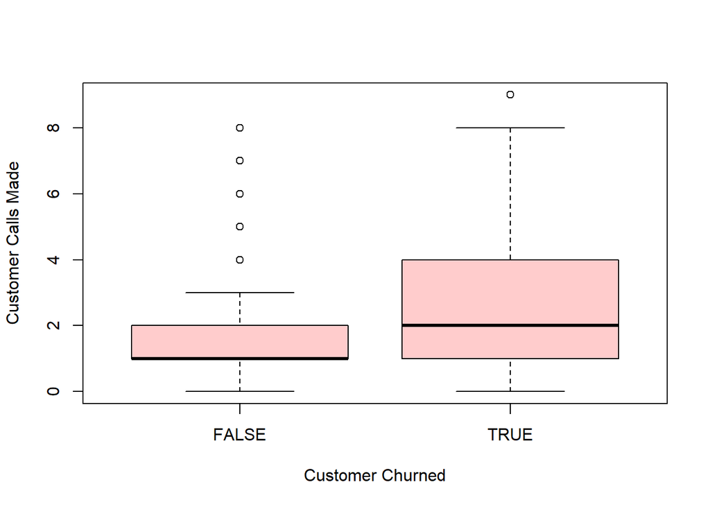

```r
boxplot(Churn_data$Customer.service.calls ~ Churn_data$Churn,  col = "#FFCCCC",
        xlab = "Customer Churned",ylab = "Customer Calls Made")
```

**Observation:-** * No. of service calls made to **churned** customer is **higher** than non churned customers.

##### **Model Building**

###### **Model1: LOGISTIC REGRESSION**

```r
library(caTools)
#Splitting the given dataset into train & test for modelling
split <-sample.split(Churn_data,SplitRatio =0.7)
split
```

```
##  [1] FALSE  TRUE  TRUE FALSE  TRUE  TRUE  TRUE FALSE  TRUE  TRUE FALSE
## [12] FALSE  TRUE  TRUE  TRUE  TRUE FALSE  TRUE  TRUE  TRUE FALSE
```

```r
train<-subset(Churn_data,split=="TRUE")
test<-subset(Churn_data,split=="FALSE")

#Check train & test data split
dim(train)
```

```
## [1] 2222   21
```

```r
dim(test)
```

```
## [1] 1111   21
```

```r
#Iteration 1
model<-glm(Churn~Account.length+Area.code+International.plan+Voice.mail.plan+Number.vmail.messages+Total.day.minutes+Total.day.calls+Total.day.charge+Total.eve.minutes+Total.eve.calls+Total.eve.charge+Total.night.minutes+Total.night.calls+Total.night.charge+Total.intl.minutes+Total.intl.calls+Total.intl.charge+Customer.service.calls,
data=train,family="binomial")
summary(model)
```

```
##
## Call:
## glm(formula = Churn ~ Account.length + Area.code + International.plan +
##     Voice.mail.plan + Number.vmail.messages + Total.day.minutes +
##     Total.day.calls + Total.day.charge + Total.eve.minutes +
##     Total.eve.calls + Total.eve.charge + Total.night.minutes +
##     Total.night.calls + Total.night.charge + Total.intl.minutes +
##     Total.intl.calls + Total.intl.charge + Customer.service.calls,
##     family = "binomial", data = train)
##
## Deviance Residuals:
##     Min       1Q   Median       3Q      Max
## -2.1808  -0.5218  -0.3365  -0.1908   2.9325
##
## Coefficients:
##                          Estimate Std. Error z value Pr(>|z|)
## (Intercept)            -9.526e+00  1.140e+00  -8.358  < 2e-16 ***
## Account.length          2.432e-03  1.722e-03   1.412  0.15788
## Area.code              -1.926e-04  1.578e-03  -0.122  0.90285
## International.planYes   2.015e+00  1.802e-01  11.185  < 2e-16 ***
## Voice.mail.planYes     -2.163e+00  7.186e-01  -3.011  0.00261 **
## Number.vmail.messages   3.875e-02  2.241e-02   1.729  0.08380 .
## Total.day.minutes      -1.539e+00  4.015e+00  -0.383  0.70147
## Total.day.calls         4.508e-03  3.426e-03   1.316  0.18823
## Total.day.charge        9.127e+00  2.362e+01   0.386  0.69914
## Total.eve.minutes       1.311e+00  1.994e+00   0.657  0.51090
## Total.eve.calls         3.542e-03  3.500e-03   1.012  0.31153
## Total.eve.charge       -1.534e+01  2.346e+01  -0.654  0.51307
## Total.night.minutes    -1.492e-01  1.061e+00  -0.141  0.88819
## Total.night.calls       5.313e-03  3.485e-03   1.525  0.12735
## Total.night.charge      3.415e+00  2.359e+01   0.145  0.88487
## Total.intl.minutes     -4.916e+00  6.490e+00  -0.758  0.44871
## Total.intl.calls       -9.649e-02  3.092e-02  -3.120  0.00181 **
## Total.intl.charge       1.852e+01  2.404e+01   0.770  0.44106
## Customer.service.calls  5.287e-01  4.754e-02  11.120  < 2e-16 ***
## ---
## Signif. codes:  0 '***' 0.001 '**' 0.01 '*' 0.05 '.' 0.1 ' ' 1
##
## (Dispersion parameter for binomial family taken to be 1)
##
##     Null deviance: 1849.5  on 2221  degrees of freedom
## Residual deviance: 1444.6  on 2203  degrees of freedom
## AIC: 1482.6
##
## Number of Fisher Scoring iterations: 6
```

```r
#After performing a couple of iterations by dropping independent variables we arrive at the following optimum model
model<-glm(Churn~International.plan+Voice.mail.plan+Total.day.charge+Total.eve.charge+Total.night.charge+Total.intl.minutes+Total.intl.calls+Total.intl.charge+Customer.service.calls,
data=train,family="binomial")
summary(model)
```

```
##
## Call:
## glm(formula = Churn ~ International.plan + Voice.mail.plan +
##     Total.day.charge + Total.eve.charge + Total.night.charge +
##     Total.intl.minutes + Total.intl.calls + Total.intl.charge +
##     Customer.service.calls, family = "binomial", data = train)
##
## Deviance Residuals:
##     Min       1Q   Median       3Q      Max
## -2.1340  -0.5234  -0.3375  -0.1978   2.9199
##
## Coefficients:
##                         Estimate Std. Error z value Pr(>|z|)
## (Intercept)            -8.019244   0.623175 -12.868  < 2e-16 ***
## International.planYes   2.035588   0.178823  11.383  < 2e-16 ***
## Voice.mail.planYes     -0.982602   0.177900  -5.523 3.33e-08 ***
## Total.day.charge        0.076049   0.007876   9.656  < 2e-16 ***
## Total.eve.charge        0.078118   0.016257   4.805 1.55e-06 ***
## Total.night.charge      0.096137   0.030482   3.154  0.00161 **
## Total.intl.minutes     -5.823512   6.470084  -0.900  0.36808
## Total.intl.calls       -0.092874   0.030714  -3.024  0.00250 **
## Total.intl.charge      21.874550  23.965619   0.913  0.36138
## Customer.service.calls  0.523260   0.047043  11.123  < 2e-16 ***
## ---
## Signif. codes:  0 '***' 0.001 '**' 0.01 '*' 0.05 '.' 0.1 ' ' 1
##
## (Dispersion parameter for binomial family taken to be 1)
##
##     Null deviance: 1849.5  on 2221  degrees of freedom
## Residual deviance: 1455.1  on 2212  degrees of freedom
## AIC: 1475.1
##
## Number of Fisher Scoring iterations: 6
```

```r
# predicting using the test data
res<-predict(model,test,type = "response")
#res
```

```r
# Confusion Matrix to check accuracy of prediction
 tab_mat<-table(Predictedvalue=res>0.5,Actualvalue=test$Churn)
tab_mat
```

```
##               Actualvalue
## Predictedvalue FALSE TRUE
##          FALSE   926  118
##          TRUE     27   40
```

**Analysis of Model performance**

```r
#Calculating Accuracy of prediction
accuracy= sum(diag(tab_mat)) / sum(tab_mat)
accuracy
```

```
## [1] 0.8694869
```

```r
#calculating sensitivity TP/(TP+FN)
sensitivity=22/(22+141)
sensitivity
```

```
## [1] 0.1349693
```

```r
#Calculating Specificity TN/TN+FP
specificity=929/(929+20)
specificity
```

```
## [1] 0.9789252
```

Since our aim is to predict the churned customer we will work on improving the model. **Plotting ROC curve**

```r
library(ROCR)
```

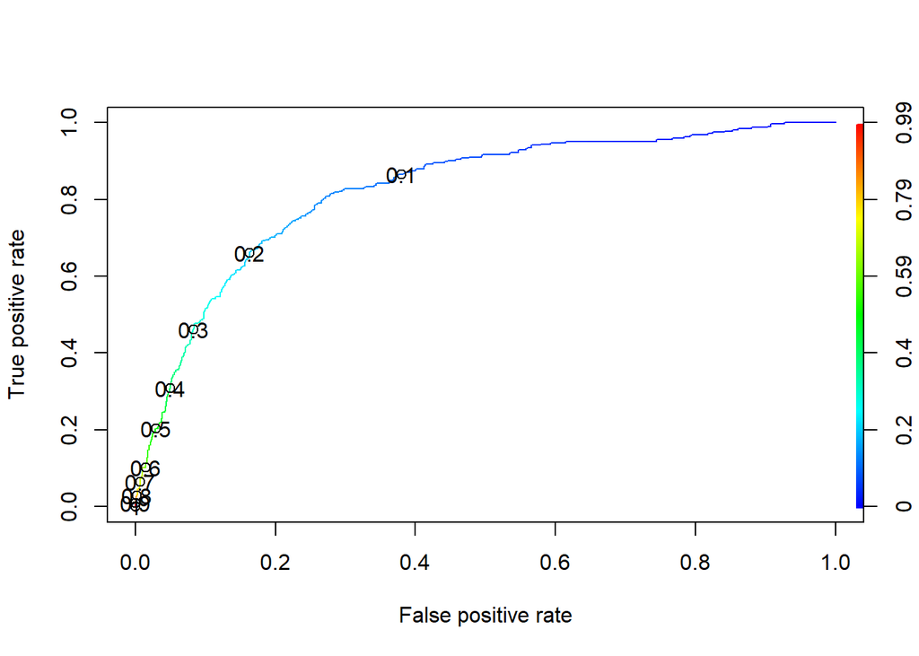

```r
res<-predict(model,train,type = "response")
ROCRpred=prediction(res,train$Churn)
ROCRperf<-performance(ROCRpred,"tpr","fpr")
plot(ROCRperf,colorize=TRUE,print.cutoffs.at=seq(0.1,by=0.1))
```

From ROC graph the new threshold is 0.2

**Create confusion matrix with new threshold (0.2)**

```r
res.logit<-predict(model,test,type = "response")
table(Predictedvalue=res.logit>0.2,Actualvalue=test$Churn)
```

```
##               Actualvalue
## Predictedvalue FALSE TRUE
##          FALSE   804   52
##          TRUE    149  106
```

```r
#Calculating Accuracy of prediction
accuracy= sum(diag(tab_mat)) / sum(tab_mat)
accuracy
```

```
## [1] 0.8694869
```

```r
#calculating sensitivity TP/(TP+FN)
sensitivity=106/(106+153)
sensitivity
```

```
## [1] 0.4092664
```

```r
#Calculating Specificity TN/TN+FP
specificity=796/(796+57)
specificity
```

```
## [1] 0.933177
```

###### **Model-2: DECISION TREE**

```r
#plotting Decision tree with train data

library(rpart)
library(rpart.plot)
tree <- rpart(Churn~Account.length+Area.code+International.plan+Voice.mail.plan+Number.vmail.messages+Total.day.minutes+Total.day.calls+Total.day.charge+Total.eve.minutes+Total.eve.calls+Total.eve.charge+Total.night.minutes+Total.night.calls+Total.night.charge+Total.intl.minutes+Total.intl.calls+Total.intl.charge+Customer.service.calls, data=train, method="class")
summary(tree)
```

```
## Call:
## rpart(formula = Churn ~ Account.length + Area.code + International.plan +
##     Voice.mail.plan + Number.vmail.messages + Total.day.minutes +
##     Total.day.calls + Total.day.charge + Total.eve.minutes +
##     Total.eve.calls + Total.eve.charge + Total.night.minutes +
##     Total.night.calls + Total.night.charge + Total.intl.minutes +
##     Total.intl.calls + Total.intl.charge + Customer.service.calls,
##     data = train, method = "class")
##   n= 2222
##
##           CP nsplit rel error    xerror       xstd
## 1 0.08717949      0 1.0000000 1.0000000 0.05125308
## 2 0.08307692      3 0.7384615 0.9200000 0.04949597
## 3 0.05384615      4 0.6553846 0.6923077 0.04375472
## 4 0.03384615      7 0.4584615 0.4676923 0.03661437
## 5 0.02153846      8 0.4246154 0.4584615 0.03627750
## 6 0.01538462     11 0.3600000 0.4338462 0.03535820
## 7 0.01230769     12 0.3446154 0.4400000 0.03559097
## 8 0.01000000     13 0.3323077 0.4338462 0.03535820
##
## Variable importance
##       Total.day.charge      Total.day.minutes Customer.service.calls
##                     16                     16                      9
##      Total.eve.minutes       Total.eve.charge     Total.intl.minutes
##                      8                      8                      7
##      Total.intl.charge       Total.intl.calls     International.plan
##                      7                      6                      5
##  Number.vmail.messages        Voice.mail.plan    Total.night.minutes
##                      5                      5                      1
##     Total.night.charge      Total.night.calls              Area.code
##                      1                      1                      1
##
## Node number 1: 2222 observations,    complexity param=0.08717949
##   predicted class=FALSE  expected loss=0.1462646  P(node) =1
##     class counts:  1897   325
##    probabilities: 0.854 0.146
##   left son=2 (2088 obs) right son=3 (134 obs)
##   Primary splits:
##       Total.day.minutes      < 264.45 to the left,  improve=59.880190, (0 missing)
##       Total.day.charge       < 44.96  to the left,  improve=59.880190, (0 missing)
```

[output cut: 242 more lines]

```
##   Surrogate splits:
##       Total.night.charge < 7.75   to the left,  agree=1.000, adj=1.000, (0 split)
##       Total.day.calls    < 71.5   to the left,  agree=0.767, adj=0.167, (0 split)
##       Total.night.calls  < 138    to the right, agree=0.767, adj=0.167, (0 split)
##       Total.intl.calls   < 8      to the right, agree=0.767, adj=0.167, (0 split)
##
## Node number 142: 12 observations
##   predicted class=FALSE  expected loss=0.3333333  P(node) =0.00540054
##     class counts:     8     4
##    probabilities: 0.667 0.333
##
## Node number 143: 31 observations
##   predicted class=TRUE   expected loss=0.09677419  P(node) =0.0139514
##     class counts:     3    28
##    probabilities: 0.097 0.903
```

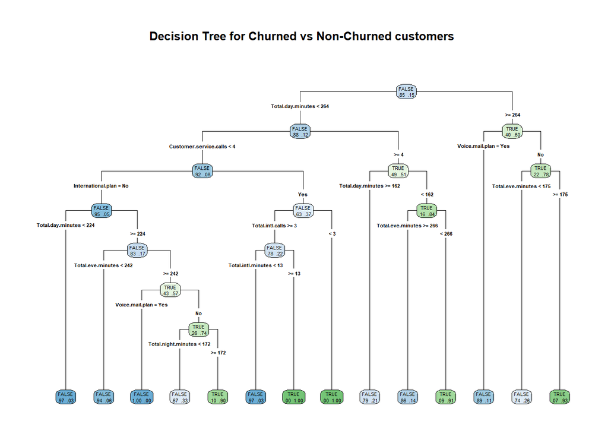

```r
#plotting the tree
rpart.plot(tree,type=4, extra=4,main="Decision Tree for Churned vs Non-Churned customers ")
```

```r
#Predict using tree model
Pred_tree<-predict(tree, test, type="class")

#Confusion matrix
table(Predictedvalue=Pred_tree,Actualvalue=test$Churn)
```

```
##               Actualvalue
## Predictedvalue FALSE TRUE
##          FALSE   938   58
##          TRUE     15  100
```

```r
#Calculating Accuracy of prediction
accuracy= sum(diag(tab_mat)) / sum(tab_mat)
accuracy
```

```
## [1] 0.8694869
```

```r
#calculating sensitivity TP/(TP+FN)
sensitivity=110/(110+53)
sensitivity
```

```
## [1] 0.6748466
```

```r
#Calculating Specificity TN/TN+FP
specificity=930/(930+19)
specificity
```

```
## [1] 0.9799789
```

```r
#summary(tree)
# visualize cross-validation results
par(mfrow=c(1,2))
rsq.rpart(tree)
```

```
##
## Classification tree:
## rpart(formula = Churn ~ Account.length + Area.code + International.plan +
##     Voice.mail.plan + Number.vmail.messages + Total.day.minutes +
##     Total.day.calls + Total.day.charge + Total.eve.minutes +
##     Total.eve.calls + Total.eve.charge + Total.night.minutes +
##     Total.night.calls + Total.night.charge + Total.intl.minutes +
##     Total.intl.calls + Total.intl.charge + Customer.service.calls,
##     data = train, method = "class")
##
## Variables actually used in tree construction:
## [1] Customer.service.calls International.plan     Total.day.minutes
## [4] Total.eve.minutes      Total.intl.calls       Total.intl.minutes
## [7] Total.night.minutes    Voice.mail.plan
##
## Root node error: 325/2222 = 0.14626
##
## n= 2222
##
##         CP nsplit rel error  xerror     xstd
## 1 0.087179      0   1.00000 1.00000 0.051253
## 2 0.083077      3   0.73846 0.92000 0.049496
## 3 0.053846      4   0.65538 0.69231 0.043755
## 4 0.033846      7   0.45846 0.46769 0.036614
## 5 0.021538      8   0.42462 0.45846 0.036278
## 6 0.015385     11   0.36000 0.43385 0.035358
## 7 0.012308     12   0.34462 0.44000 0.035591
## 8 0.010000     13   0.33231 0.43385 0.035358
```

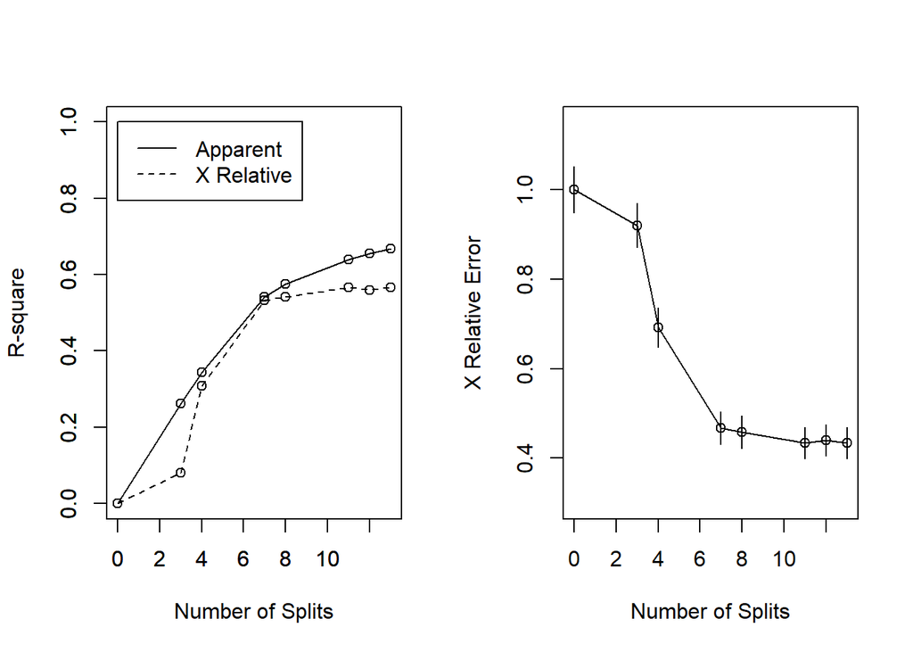

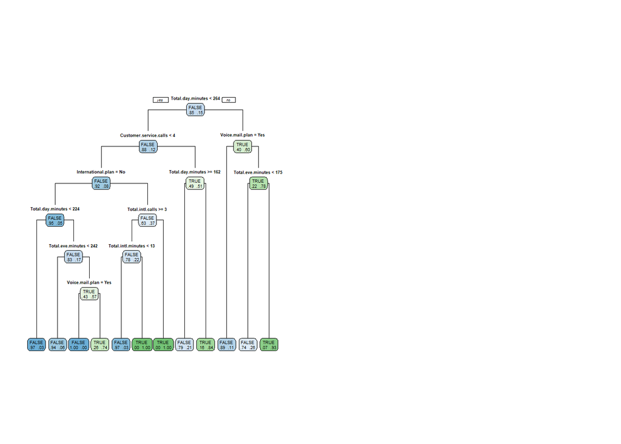

```r
# prune the tree

pruned.tree <- prune(tree, cp = tree$cptable[which.min(tree$cptable[,"xerror"]),"CP"])
rpart.plot(pruned.tree,type=1, extra=4)
```

```r
#Predict using tree model
Pred_tree<-predict(pruned.tree, test, type="class")

#Confusion matrix
table(Predictedvalue=Pred_tree,Actualvalue=test$Churn)
```

```
##               Actualvalue
## Predictedvalue FALSE TRUE
##          FALSE   934   57
##          TRUE     19  101
```

###### **MODEL 3: RANDOM FOREST**

```r
library(randomForest)
library(caret)
#set random seed
set.seed(51)
rf<-randomForest(as.factor(Churn)~Account.length+Area.code+International.plan+Voice.mail.plan+Number.vmail.messages+Total.day.minutes+Total.day.calls+Total.day.charge+Total.eve.minutes+Total.eve.calls+Total.eve.charge+Total.night.minutes+Total.night.calls+Total.night.charge+Total.intl.minutes+Total.intl.calls+Total.intl.charge+Customer.service.calls, data = train, type=classification)
print(rf)
```

```
##
## Call:
##  randomForest(formula = as.factor(Churn) ~ Account.length + Area.code +      International.plan + Voice.mail.plan + Number.vmail.messages +      Total.day.minutes + Total.day.calls + Total.day.charge +      Total.eve.minutes + Total.eve.calls + Total.eve.charge +      Total.night.minutes + Total.…
##                Type of random forest: classification
##                      Number of trees: 500
## No. of variables tried at each split: 4
##
##         OOB estimate of  error rate: 5.22%
## Confusion matrix:
##       FALSE TRUE class.error
## FALSE  1875   22  0.01159726
## TRUE     94  231  0.28923077
```

Prediction & confusion matrix

```r
#library(e1071)
#Prediction
pred_rf <- predict(rf, test)

#confusion matrix
Conf_Matrix<-table(Predicted=pred_rf, Actual=test$Churn)
Conf_Matrix
```

```
##          Actual
## Predicted FALSE TRUE
##     FALSE   945   41
##     TRUE      8  117
```

```r
#calculating sensitivity TP/(TP+FN)
sensitivity=113/(113+47)
sensitivity
```

```
## [1] 0.70625
```

```r
#Calculating Specificity TN/TN+FP
specificity=945/(945+8)
specificity
```

```
## [1] 0.9916055
```

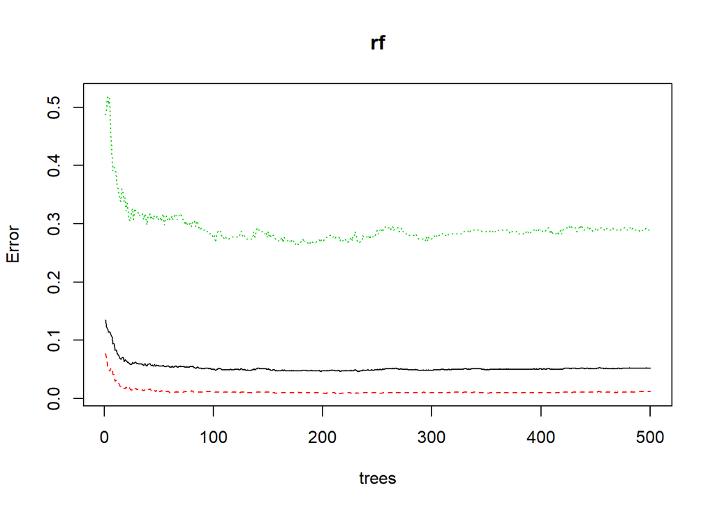

```r
#Error rate in Random Forest model
plot(rf)
```

```
## mtry = 6  OOB error = 0.0004236821
## Searching left ...
```

```
## mtry = 12    OOB error = 2.955118e-05
## 0.9302515 0.05
```

```
## mtry = 24    OOB error = 5.685986e-05
## -0.9241147 0.05
## Searching right ...
```

```
## mtry = 3     OOB error = 0.003442997
## -115.5096 0.05
```

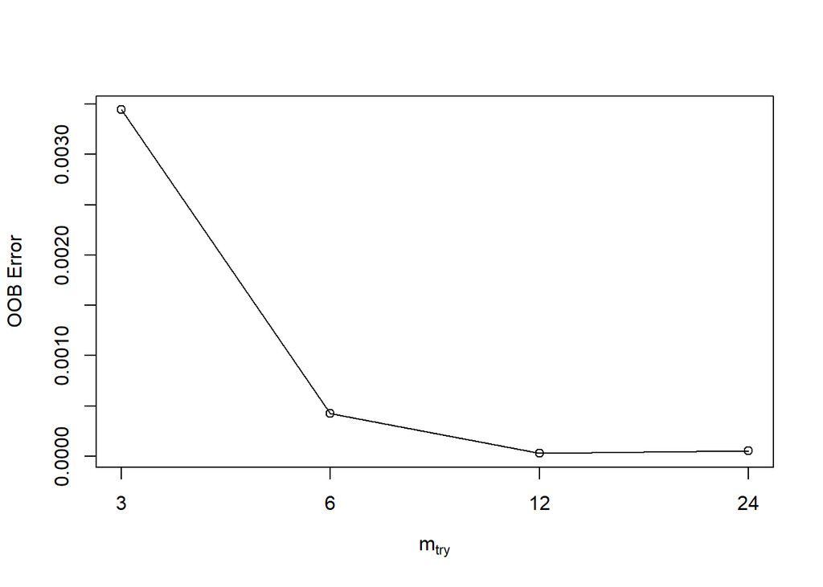

```
##    mtry     OOBError
## 3     3 3.442997e-03
## 6     6 4.236821e-04
## 12   12 2.955118e-05
## 24   24 5.685986e-05
```

```r
#Tune mtry
train1=train
train1$Id=NULL
train1$State=NULL

tuneRF(train1[,-21], train[,21], stepFactor = 0.5, plot=TRUE, ntreeTry = 100, trace = TRUE, improve=0.05)
```

From the plots above it is observed that 100 tree is ideal & error is at lowest at mtry 12

```r
#Tuned model after changing mtry & ntree
rf.tune<-randomForest(as.factor(Churn)~Account.length+Area.code+International.plan+Voice.mail.plan+Number.vmail.messages+Total.day.minutes+Total.day.calls+Total.day.charge+Total.eve.minutes+Total.eve.calls+Total.eve.charge+Total.night.minutes+Total.night.calls+Total.night.charge+Total.intl.minutes+Total.intl.calls+Total.intl.charge+Customer.service.calls, data = train, ntree=100, mtry=12, importance=TRUE, proximity=TRUE)

print(rf.tune)
```

```
##
## Call:
##  randomForest(formula = as.factor(Churn) ~ Account.length + Area.code +      International.plan + Voice.mail.plan + Number.vmail.messages +      Total.day.minutes + Total.day.calls + Total.day.charge +      Total.eve.minutes + Total.eve.calls + Total.eve.charge +      Total.night.minutes + Total.…
##                Type of random forest: classification
##                      Number of trees: 100
## No. of variables tried at each split: 12
##
##         OOB estimate of  error rate: 5.09%
## Confusion matrix:
##       FALSE TRUE class.error
## FALSE  1869   28  0.01476015
## TRUE     85  240  0.26153846
```

Predict with test date after model tuning

```r
#Prediction
pred.tune <- predict(rf.tune, test)

#confusion matrix
Conf_Matrix<-table(Predicted=pred.tune, Actual=test$Churn)
Conf_Matrix
```

```
##          Actual
## Predicted FALSE TRUE
##     FALSE   933   45
##     TRUE     20  113
```

Accuracy test & additional diagnostic

```r
#Accuracy
accuracy<- sum(diag(Conf_Matrix))/sum(Conf_Matrix)
accuracy
```

```
## [1] 0.9414941
```

```r
#Sensitivity
Sensitivity<-116/(116+44)
Sensitivity
```

```
## [1] 0.725
```

```r
#Specificity
Specificity<-941/(941+12)
Specificity
```

```
## [1] 0.9874082
```

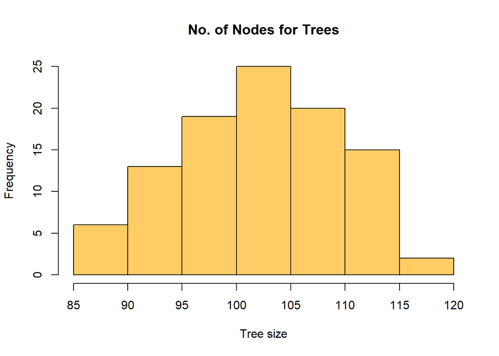

```r
#No. of Nodes for Trees
hist(treesize(rf.tune), main="No. of Nodes for Trees",xlab = "Tree size", col='#FFCC66')
```

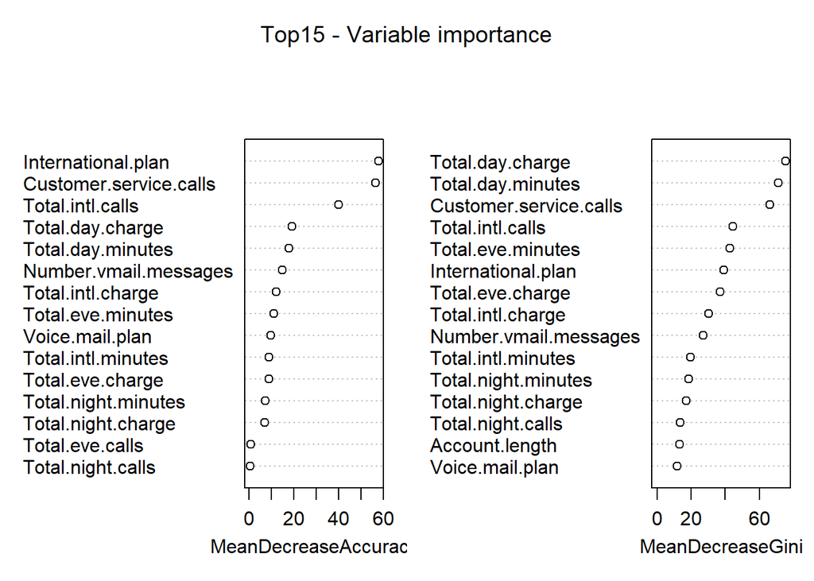

```r
#Variable Importance
varImpPlot(rf.tune, sort=T, n.var=15, main="Top15 - Variable importance")
```

```r
#Importance of variables - actual data points used to plot the graph
importance(rf.tune)
```

```
##                             FALSE        TRUE MeanDecreaseAccuracy
## Account.length         -0.6559231 -0.03503492           -0.6542107
## Area.code              -0.7590878 -0.47475167           -0.9158997
## International.plan     36.6326336 54.60316307           57.8515316
## Voice.mail.plan         8.0581864  8.76726940            9.6534460
## Number.vmail.messages  11.4129926 13.31232078           14.8322978
## Total.day.minutes      13.2026432 15.26069789           17.7347264
## Total.day.calls         0.3819180 -0.44265980            0.2557138
## Total.day.charge       14.5382133 14.79388325           19.2241493
## Total.eve.minutes       8.1031044 13.14138934           11.0378509
## Total.eve.calls         1.2289395 -0.98908823            0.7136298
## Total.eve.charge        6.9791679 10.80269247            8.7711100
## Total.night.minutes     6.5762275  4.02305000            7.1790910
## Total.night.calls       0.9094715 -1.41094885            0.3535796
## Total.night.charge      6.5987830  2.37699610            6.9893410
## Total.intl.minutes      7.3545881  7.35280383            8.9644008
## Total.intl.calls       22.8778236 38.76952022           39.9653835
## Total.intl.charge      10.5588824 10.75175474           12.1988730
## Customer.service.calls 29.4285557 48.32888158           56.6571790
##                        MeanDecreaseGini
## Account.length                 13.38149
## Area.code                       3.22527
## International.plan             38.99253
## Voice.mail.plan                11.92780
## Number.vmail.messages          26.95388
## Total.day.minutes              71.22291
## Total.day.calls                11.58001
## Total.day.charge               75.17822
## Total.eve.minutes              42.83312
## Total.eve.calls                11.91678
## Total.eve.charge               37.02430
## Total.night.minutes            18.41797
## Total.night.calls              13.58944
## Total.night.charge             17.21966
## Total.intl.minutes             19.69194
## Total.intl.calls               44.40609
## Total.intl.charge              30.11904
## Customer.service.calls         65.97500
```

```r
#Variables actually used by the model
varUsed(rf.tune)
```

```
##  [1] 686 169 176  93 491 843 668 886 887 603 792 695 732 660 454 457 528
## [18] 333
```